```python
import pandas as pd
import numpy as np
import matplotlib.pyplot as plt
import seaborn as sns

from factor_analyzer.factor_analyzer import calculate_bartlett_sphericity, calculate_kmo

from sklearn.preprocessing import StandardScaler
from sklearn.decomposition import PCA
from sklearn.linear_model import LogisticRegression
from sklearn.model_selection import StratifiedKFold, cross_val_predict, train_test_split
from sklearn.metrics import roc_auc_score, accuracy_score, silhouette_score, calinski_harabasz_score
from sklearn.cluster import KMeans

from scipy.cluster.hierarchy import dendrogram, linkage
from scipy.stats import kruskal, chi2_contingency

import warnings

warnings.filterwarnings('ignore')
```

# Análisis multivariante sobre los tipos de consumo

## Análisis de Componentes Principales

Primero vamos a hacer el acp básico, cogiendo las componentes que expliquen más de un 75% de la variabilidad para imputar la variables sector público, y posteriormente haremos el análisis definitivo.

```python
datos = pd.read_csv('..//datos_procesados/datos_iniciales.csv')
proporciones = [col for col in datos.columns if col.startswith('prop_')]

seed = 111104

datos_train, datos_test = train_test_split(datos, test_size=0.3, random_state=seed)

print(f"Datos de entrenamiento: {datos_train.shape[0]} hogares")
print(f"Datos de prueba: {datos_test.shape[0]} hogares")
```

```
Datos de entrenamiento: 14493 hogares
Datos de prueba: 6212 hogares
```

```python
datos_prop_train = datos_train[proporciones]
datos_prop_test = datos_test[proporciones]

print("Dimensiones de datos_prop_train:", datos_prop_train.shape)
print("Dimensiones de datos_prop_test:", datos_prop_test.shape)
```

```
Dimensiones de datos_prop_train: (14493, 12)
Dimensiones de datos_prop_test: (6212, 12)
```

```python
chi_square, p_value = calculate_bartlett_sphericity(datos_prop_train)

kmo_all, kmo_model = calculate_kmo(datos_prop_train)

print(f"Chi-cuadrado de Bartlett: {chi_square}")
print(f"Valor p: {p_value}")
print(f"Medida KMO global: {kmo_model.round(4)}")
```

```
Chi-cuadrado de Bartlett: nan
Valor p: nan
Medida KMO global: 0.2775
```

### Imputación de sector público

```python
print("Proporción de valores nulos en 'sector_publico' en datos_train:")
print(sum(datos_train["sector_publico"].isna())/datos_train.shape[0])
print("Proporción de valores nulos en 'sector_publico' en datos_test:")
print(sum(datos_test["sector_publico"].isna())/datos_test.shape[0])
print("Proporción de valores nulos en 'sector_publico' en datos:")
print(sum(datos["sector_publico"].isna())/datos.shape[0])
```

```
Proporción de valores nulos en 'sector_publico' en datos_train:
0.09701235079003658
Proporción de valores nulos en 'sector_publico' en datos_test:
0.09867997424339987
Proporción de valores nulos en 'sector_publico' en datos:
0.097512678097078
```

```python
escalador_imp = StandardScaler()
datos_prop_train_escalados = escalador_imp.fit_transform(datos_prop_train)
pca_imp = PCA()
pca_imp.fit_transform(datos_prop_train_escalados)

tabla_acp = pd.DataFrame({
    "Componente": [f"CP{i+1}" for i in range(len(proporciones))],
    "Autovalor": pca_imp.explained_variance_,
    "% varianza explicada": pca_imp.explained_variance_ratio_ * 100,
    "% varianza acumulada": np.cumsum(pca_imp.explained_variance_ratio_) * 100
})

display(tabla_acp)
```

|  | Componente | Autovalor | % varianza explicada | % varianza acumulada |
| --- | --- | --- | --- | --- |
| 0 | CP1 | 1.847831e+00 | 1.539753e+01 | 15.397526 |
| 1 | CP2 | 1.255109e+00 | 1.045852e+01 | 25.856048 |
| 2 | CP3 | 1.177191e+00 | 9.809246e+00 | 35.665294 |
| 3 | CP4 | 1.082373e+00 | 9.019149e+00 | 44.684443 |
| 4 | CP5 | 1.023097e+00 | 8.525217e+00 | 53.209660 |
| 5 | CP6 | 1.019625e+00 | 8.496289e+00 | 61.705949 |
| 6 | CP7 | 9.729802e-01 | 8.107609e+00 | 69.813558 |
| 7 | CP8 | 9.419981e-01 | 7.849443e+00 | 77.663001 |
| 8 | CP9 | 9.394361e-01 | 7.828094e+00 | 85.491095 |
| 9 | CP10 | 8.949294e-01 | 7.457230e+00 | 92.948325 |
| 10 | CP11 | 8.462594e-01 | 7.051675e+00 | 100.000000 |
| 11 | CP12 | 4.033232e-17 | 3.360795e-16 | 100.000000 |

Cogeremos 8 componentes para la imputación, + las variables edad, nivel de estudios y tamaño del municipio

```python
coordenadas_train = pca_imp.transform(datos_prop_train_escalados)
componentes_train_df = pd.DataFrame(
    coordenadas_train,
    columns=[f"CP{i+1}" for i in range(len(proporciones))],
    index=datos_train.index
)

datos_prop_test_escalados_imp = escalador_imp.transform(datos_prop_test)
coordenadas_test = pca_imp.transform(datos_prop_test_escalados_imp)
componentes_test_df = pd.DataFrame(
    coordenadas_test,
    columns=[f"CP{i+1}" for i in range(len(proporciones))],
    index=datos_test.index
)

for i in range(1, 9):
    datos_train[f"CP{i}"] = componentes_train_df[f"CP{i}"]
    datos_test[f"CP{i}"] = componentes_test_df[f"CP{i}"]

variables_componentes = [f"CP{i}" for i in range(1, 9)]
variables_sociodemograficas = ['edad', 'estudios', 'tam_municipio']

datos_sociodemograficos_dummies_train = pd.get_dummies(datos_train[variables_sociodemograficas], drop_first=True)
datos_sociodemograficos_dummies_test = pd.get_dummies(datos_test[variables_sociodemograficas], drop_first=True)
datos_sociodemograficos_dummies_test = datos_sociodemograficos_dummies_test.reindex(columns=datos_sociodemograficos_dummies_train.columns, fill_value=0)

X_total_train = pd.concat([datos_train[variables_componentes], datos_sociodemograficos_dummies_train], axis=1)
X_total_test = pd.concat([datos_test[variables_componentes], datos_sociodemograficos_dummies_test], axis=1)

datos_obs_train = datos_train[datos_train["sector_publico"].notna()].copy()
X_obs_train = X_total_train.loc[datos_obs_train.index]
y_obs_train = datos_obs_train["sector_publico"].astype(int)

datos_train["sector_publico_imp"] = datos_train["sector_publico"]
datos_test["sector_publico_imp"] = datos_test["sector_publico"]

datos_mis_train = datos_train[datos_train["sector_publico"].isna()]
datos_mis_test = datos_test[datos_test["sector_publico"].isna()]

X_mis_train = X_total_train.loc[datos_mis_train.index]
X_mis_test = X_total_test.loc[datos_mis_test.index]

cv = StratifiedKFold(
    n_splits=5,
    shuffle=True,
    random_state=111104
)

modelo = LogisticRegression(max_iter=2000, random_state=111104)

resultados = []

prob_cv = cross_val_predict(
    modelo,
    X_obs_train,
    y_obs_train,
    cv=cv,
    method="predict_proba"
)[:, 1]

pred_cv = (prob_cv >= 0.5).astype(int)

tabla_validacion_imp = pd.DataFrame({
        "AUC CV": roc_auc_score(y_obs_train, prob_cv),
        "Accuracy CV": accuracy_score(y_obs_train, pred_cv),
        "% predicho como sector_publico=1": pred_cv.mean() * 100
        }, index=[0])

display(tabla_validacion_imp.round(4))
```

|  | AUC CV | Accuracy CV | % predicho como sector_publico=1 |
| --- | --- | --- | --- |
| 0 | 0.7233 | 0.7734 | 10.0481 |

```python
modelo_final_imputacion = LogisticRegression(max_iter=2000, random_state=111104)
modelo_final_imputacion.fit(X_obs_train, y_obs_train)

rng = np.random.default_rng(seed=111104)

if not X_mis_train.empty:
    prob_mis_train = modelo_final_imputacion.predict_proba(X_mis_train)[:, 1]
    datos_train.loc[datos_train["sector_publico"].isna(), "sector_publico_imp"] = rng.binomial(n=1, p=prob_mis_train)

if not X_mis_test.empty:
    prob_mis_test = modelo_final_imputacion.predict_proba(X_mis_test)[:, 1]
    datos_test.loc[datos_test["sector_publico"].isna(), "sector_publico_imp"] = rng.binomial(n=1, p=prob_mis_test)

datos_train["sector_publico_imp"] = datos_train["sector_publico_imp"].astype(int)
datos_test["sector_publico_imp"] = datos_test["sector_publico_imp"].astype(int)

print("Missing en sector_publico_imp:")
print(datos_train["sector_publico_imp"].isna().sum())

print("\nDistribución observada original:")
print(datos_train["sector_publico"].value_counts(normalize=True, dropna=True))

print("\nDistribución final tras imputación:")
print(datos_train["sector_publico_imp"].value_counts(normalize=True))
```

```
Missing en sector_publico_imp:
0

Distribución observada original:
sector_publico
0.0    0.764193
1.0    0.235807
Name: proportion, dtype: float64

Distribución final tras imputación:
sector_publico_imp
0    0.764162
1    0.235838
Name: proportion, dtype: float64
```

```python
datos_train['particion'] = 'train'
datos_test['particion'] = 'test'
datos = pd.concat([datos_train, datos_test], axis=0)

for i in range(1, 9):
    if f"CP{i}" in datos.columns:
        del(datos[f"CP{i}"])
```

### ACP principal

```python
escalador = StandardScaler()

datos_prop_train_escalados = escalador.fit_transform(datos_prop_train)
datos_prop_test_escalados = escalador.transform(datos_prop_test)
pca = PCA()
pca.fit_transform(datos_prop_train_escalados)

tabla_acp = pd.DataFrame({
    "Componente": [f"CP{i+1}" for i in range(len(proporciones))],
    "Autovalor": pca.explained_variance_,
    "% varianza explicada": pca.explained_variance_ratio_ * 100,
    "% varianza acumulada": np.cumsum(pca.explained_variance_ratio_) * 100
})

autovalores = tabla_acp["Autovalor"]
prop_varianza = tabla_acp["% varianza explicada"]/100
prop_acumulada = tabla_acp["% varianza acumulada"]/100

p = len(proporciones)

display(tabla_acp.round(5))
```

|  | Componente | Autovalor | % varianza explicada | % varianza acumulada |
| --- | --- | --- | --- | --- |
| 0 | CP1 | 1.84783 | 15.39753 | 15.39753 |
| 1 | CP2 | 1.25511 | 10.45852 | 25.85605 |
| 2 | CP3 | 1.17719 | 9.80925 | 35.66529 |
| 3 | CP4 | 1.08237 | 9.01915 | 44.68444 |
| 4 | CP5 | 1.02310 | 8.52522 | 53.20966 |
| 5 | CP6 | 1.01963 | 8.49629 | 61.70595 |
| 6 | CP7 | 0.97298 | 8.10761 | 69.81356 |
| 7 | CP8 | 0.94200 | 7.84944 | 77.66300 |
| 8 | CP9 | 0.93944 | 7.82809 | 85.49109 |
| 9 | CP10 | 0.89493 | 7.45723 | 92.94833 |
| 10 | CP11 | 0.84626 | 7.05167 | 100.00000 |
| 11 | CP12 | 0.00000 | 0.00000 | 100.00000 |

La 12ª componente nos sale sin autovalor y sin varianza explicada, debido a la composición de los datos, ya que todas las variables de proporciones suman 1.

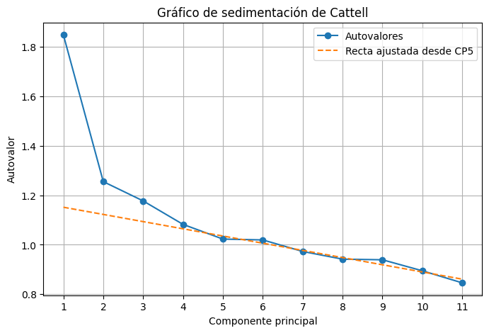

```python
m_65 = np.argmax(prop_acumulada >= 0.65) + 1
m_70 = np.argmax(prop_acumulada >= 0.70) + 1
m_75 = np.argmax(prop_acumulada >= 0.75) + 1
m_80 = np.argmax(prop_acumulada >= 0.80) + 1

m_autovalor_1 = np.sum(autovalores > 1)

gk = np.array([
    (1 / p) * sum(1 / i for i in range(k, p + 1))
    for k in range(1, p + 1)
])

retiene_gk = prop_varianza > gk
m_gk = np.sum(retiene_gk)

autovalores_cattell = autovalores[autovalores > 1e-8]
componentes = np.arange(1, len(autovalores_cattell) + 1)

inicio_recta = 5

x_recta = componentes[inicio_recta - 1:]
y_recta = autovalores_cattell[inicio_recta - 1:]

coef = np.polyfit(x_recta, y_recta, deg=1)
recta = np.polyval(coef, componentes)

plt.figure(figsize=(8, 5))

plt.plot(
    componentes,
    autovalores_cattell,
    marker="o",
    label="Autovalores"
)

plt.plot(
    componentes,
    recta,
    linestyle="--",
    label=f"Recta ajustada desde CP{inicio_recta}"
)

plt.xlabel("Componente principal")
plt.ylabel("Autovalor")
plt.title("Gráfico de sedimentación de Cattell")
plt.xticks(componentes)
plt.grid(True)
plt.legend()
plt.show()
```

```python
resumen_retencion = pd.DataFrame({
    "Criterio": [
        "Varianza acumulada ≥ 65%",
        "Varianza acumulada ≥ 70%",
        "Varianza acumulada ≥ 75%",
        "Varianza acumulada ≥ 80%",
        "Kaiser: autovalor > 1",
        "Proporción mínima g_k",
        "Catell"
    ],
    "Número de componentes sugerido": [
        m_65,
        m_70,
        m_75,
        m_80,
        m_autovalor_1,
        m_gk,
        "3-4"
    ]
})


n_componentes = 8

cargas = pca.components_[:n_componentes].T * np.sqrt(pca.explained_variance_[:n_componentes])

matriz_cargas = pd.DataFrame(
    cargas,
    index=proporciones,
    columns=[f"CP{i+1}" for i in range(n_componentes)]
)

print("Resumen de criterios para selección de componentes principales")
display(resumen_retencion)
print("\nMatriz de cargas (hasta CP8)")
display(matriz_cargas.round(3))
```

```
Resumen de criterios para selección de componentes principales
```

|  | Criterio | Número de componentes sugerido |
| --- | --- | --- |
| 0 | Varianza acumulada ≥ 65% | 7 |
| 1 | Varianza acumulada ≥ 70% | 8 |
| 2 | Varianza acumulada ≥ 75% | 8 |
| 3 | Varianza acumulada ≥ 80% | 9 |
| 4 | Kaiser: autovalor > 1 | 6 |
| 5 | Proporción mínima g_k | 7 |
| 6 | Catell | 3-4 |

```
Matriz de cargas (hasta CP8)
```

|  | CP1 | CP2 | CP3 | CP4 | CP5 | CP6 | CP7 | CP8 |
| --- | --- | --- | --- | --- | --- | --- | --- | --- |
| prop_alimentacion | 0.370 | 0.734 | -0.146 | -0.163 | -0.037 | -0.089 | 0.336 | 0.172 |
| prop_alcohol_tabaco | 0.003 | 0.305 | -0.390 | -0.509 | -0.088 | 0.279 | -0.164 | -0.369 |
| prop_ropa_calzado | -0.319 | 0.066 | 0.406 | -0.222 | -0.115 | -0.097 | 0.020 | 0.337 |
| prop_vivienda | 0.775 | -0.515 | -0.032 | 0.085 | 0.222 | 0.030 | 0.028 | 0.032 |
| prop_mobiliario | -0.018 | 0.360 | 0.361 | 0.150 | 0.598 | -0.231 | -0.308 | -0.288 |
| prop_salud | -0.076 | 0.198 | 0.116 | 0.610 | -0.249 | 0.671 | 0.057 | -0.086 |
| prop_transporte | -0.532 | -0.057 | -0.517 | 0.322 | -0.255 | -0.466 | -0.162 | 0.069 |
| prop_comunicaciones | 0.361 | -0.243 | 0.070 | -0.336 | -0.350 | 0.029 | -0.150 | 0.065 |
| prop_ocio_cultura | -0.430 | -0.016 | 0.171 | -0.206 | 0.215 | 0.278 | -0.009 | 0.542 |
| prop_educacion | -0.265 | -0.168 | 0.222 | -0.065 | -0.039 | -0.168 | 0.774 | -0.352 |
| prop_hoteles_restaurantes | -0.573 | -0.294 | -0.017 | -0.285 | 0.156 | 0.252 | -0.089 | -0.311 |
| prop_bienes_servicios | 0.079 | 0.090 | 0.586 | -0.034 | -0.521 | -0.182 | -0.278 | -0.220 |

Se seleccionan 8 componentes principales basandose en los siguientes criterios:

- Se logra capturar el 77% de la varianza total. Si nos fijaásemos en el criterio de Kaiser, el del autovalor superior a 1, nos quedaríamos con 6, pero solo tendríamos un 61% de varianza explicado, un valor muy bajo si queremos interpretabilidad real y útil, y una buena predicción posterior, ya que al pasar a 8 estaríamos ganando un 16% de varianza explicada.

```python
def varimax_rotation(loadings, max_iter=1000, tol=1e-7):
    n_rows, n_cols = loadings.shape
    rotation_matrix = np.eye(n_cols)
    d = 0
    for i in range(max_iter):
        d_old = d
        transformed_loadings = np.dot(loadings, rotation_matrix)
        u, s, vh = np.linalg.svd(np.dot(loadings.T, transformed_loadings**3 -
                                (1.0/n_rows) * np.dot(transformed_loadings,
                                 np.diag(np.sum(transformed_loadings**2, axis=0)))))
        rotation_matrix = np.dot(u, vh)
        d = np.sum(s)
        if d_old != 0 and d/d_old < 1 + tol: break
    return np.dot(loadings, rotation_matrix), rotation_matrix

n_componentes = 8
cargas_originales = pca.components_[:n_componentes].T * np.sqrt(pca.explained_variance_[:n_componentes])
cargas_rotadas, matriz_rotacion = varimax_rotation(cargas_originales)

matriz_cargas_rotadas = pd.DataFrame(
    cargas_rotadas,
    index=proporciones,
    columns=[f"CP{i+1}" for i in range(n_componentes)]
)

print("Matriz de cargas tras rotación Varimax (hasta CP8)")
display(matriz_cargas_rotadas.round(3))
```

```
Matriz de cargas tras rotación Varimax (hasta CP8)
```

|  | CP1 | CP2 | CP3 | CP4 | CP5 | CP6 | CP7 | CP8 |
| --- | --- | --- | --- | --- | --- | --- | --- | --- |
| prop_alimentacion | 0.103 | 0.912 | -0.063 | -0.161 | 0.024 | -0.028 | 0.017 | 0.027 |
| prop_alcohol_tabaco | 0.047 | 0.092 | -0.032 | -0.850 | -0.060 | -0.048 | -0.105 | -0.045 |
| prop_ropa_calzado | 0.012 | 0.007 | 0.261 | 0.161 | -0.033 | -0.136 | 0.079 | 0.580 |
| prop_vivienda | 0.517 | -0.093 | -0.189 | 0.356 | -0.176 | -0.188 | -0.189 | -0.621 |
| prop_mobiliario | 0.089 | 0.003 | 0.066 | 0.030 | 0.922 | -0.063 | -0.069 | -0.005 |
| prop_salud | 0.041 | -0.016 | 0.028 | 0.026 | -0.042 | 0.974 | -0.031 | 0.010 |
| prop_transporte | -0.967 | -0.111 | -0.068 | 0.055 | -0.088 | -0.067 | -0.043 | -0.014 |
| prop_comunicaciones | 0.267 | -0.039 | 0.325 | -0.058 | -0.411 | -0.226 | -0.191 | -0.136 |
| prop_ocio_cultura | 0.113 | -0.144 | -0.239 | 0.106 | -0.063 | -0.007 | -0.113 | 0.745 |
| prop_educacion | 0.021 | -0.039 | 0.004 | 0.057 | -0.052 | -0.032 | 0.947 | 0.008 |
| prop_hoteles_restaurantes | -0.035 | -0.627 | -0.125 | -0.398 | 0.051 | -0.028 | 0.219 | 0.264 |
| prop_bienes_servicios | 0.051 | -0.028 | 0.883 | 0.032 | 0.062 | 0.046 | 0.007 | -0.007 |

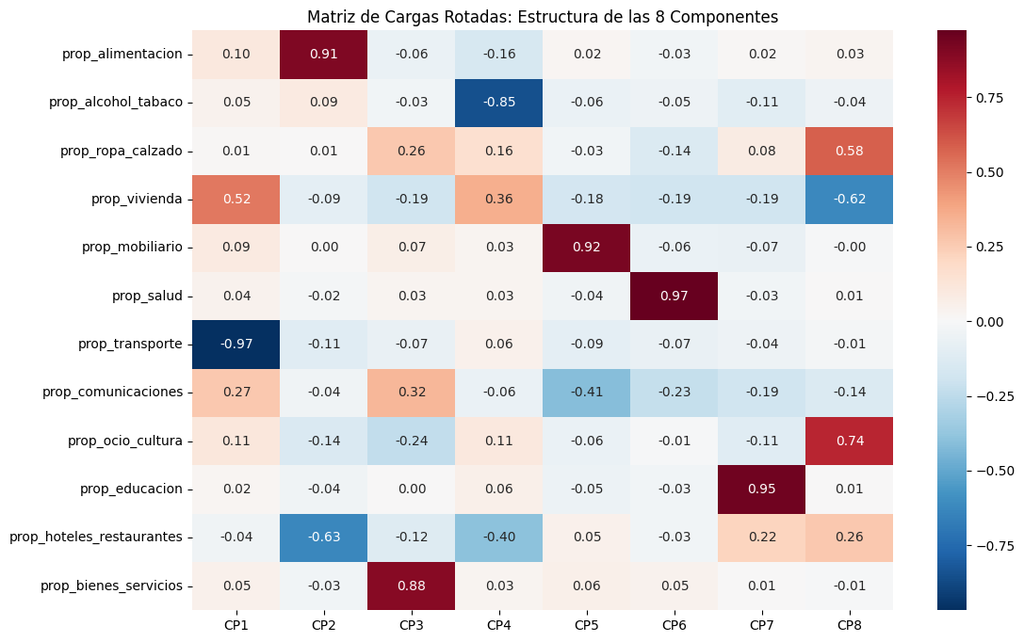

```python
plt.figure(figsize=(12, 8))
sns.heatmap(matriz_cargas_rotadas, annot=True, cmap='RdBu_r', center=0, fmt=".2f")
plt.title("Matriz de Cargas Rotadas: Estructura de las 8 Componentes")
plt.show()
```

```python
coordenadas_hogares_train = pca.transform(datos_prop_train_escalados)[:, :n_componentes]
coordenadas_hogares_test = pca.transform(datos_prop_test_escalados)[:, :n_componentes]

coordenadas_hogares_train_rot = np.dot(coordenadas_hogares_train, matriz_rotacion)
coordenadas_hogares_test_rot = np.dot(coordenadas_hogares_test, matriz_rotacion)

for i in range(1, 9):
    datos_train[f"CP{i}"] = coordenadas_hogares_train_rot[:, i-1]
    datos_test[f"CP{i}"] = coordenadas_hogares_test_rot[:, i-1]
```

```python
def plot_pca_complete_analysis(loadings, contribuciones, pca, pc_x, pc_y):
    fig, axes = plt.subplots(1, 3, figsize=(20, 6))

    ax_biplot = axes[0]
    for i, var in enumerate(loadings.index):
        var_clean = var.replace('prop_', '')

        x = loadings.iloc[i, pc_x-1]
        y = loadings.iloc[i, pc_y-1]

        var_rotada = np.var(coordenadas_hogares_train_rot, axis=0, ddof=1)
        var_pct_rotada = var_rotada / np.sum(pca.explained_variance_) * 100

        ax_biplot.arrow(0, 0, x, y, color='r', alpha=0.5, head_width=0.02)
        ax_biplot.text(x * 1.15, y * 1.15, var_clean, color='darkgreen',
                       ha='center', va='center', fontsize=9, fontweight='bold')

    circle = plt.Circle((0,0), 1, color='navy', fill=False, linestyle='--')
    ax_biplot.add_artist(circle)

    ax_biplot.set_xlim(-1.2, 1.2)
    ax_biplot.set_ylim(-1.2, 1.2)
    ax_biplot.axhline(0, color='black', lw=1)
    ax_biplot.axvline(0, color='black', lw=1)
    ax_biplot.set_title(f'Mapa de Variables: CP{pc_x} vs CP{pc_y}')
    ax_biplot.set_xlabel(f'CP{pc_x} ({var_pct_rotada[pc_x-1]:.2f}%)')
    ax_biplot.set_ylabel(f'CP{pc_y} ({var_pct_rotada[pc_y-1]:.2f}%)')
    ax_biplot.grid(True, alpha=0.3)

    pcs_to_plot = [pc_x, pc_y]
    mean_contribution = 100 / len(loadings)

    for i, pc_idx in enumerate(pcs_to_plot):
        ax_bar = axes[i+1]
        cp_name = f"CP{pc_idx}"

        data_plot = contribuciones[cp_name].sort_values(ascending=False)
        data_plot.index = [idx.replace('prop_', '') for idx in data_plot.index]

        data_plot.plot(kind='bar', color='skyblue', ax=ax_bar)
        ax_bar.axhline(y=mean_contribution, color='red', linestyle='--', label='Media')

        ax_bar.set_title(f"Contribucion a la {cp_name}")
        ax_bar.set_ylabel("Contribucion (%)")
        ax_bar.tick_params(axis='x', rotation=45)

    plt.tight_layout()
    plt.show()

def plot_pca_biplot(ax, loadings, pca, pc_x, pc_y, coords_rot=None):

    if coords_rot is None:
        coords_rot = coordenadas_hogares_train_rot

    var_rotada = np.var(coords_rot, axis=0, ddof=1)
    var_pct_rotada = var_rotada / np.sum(pca.explained_variance_) * 100

    for i, var in enumerate(loadings.index):
        var_clean = var.replace('prop_', '')
        x = loadings.iloc[i, pc_x-1]
        y = loadings.iloc[i, pc_y-1]
        ax.arrow(0, 0, x, y, color='r', alpha=0.5, head_width=0.02)
        ax.text(x * 1.15, y * 1.15, var_clean, color='darkgreen',
                ha='center', va='center', fontsize=9, fontweight='bold')

    circle = plt.Circle((0, 0), 1, color='navy', fill=False, linestyle='--')
    ax.add_artist(circle)
    ax.set_xlim(-1.2, 1.2)
    ax.set_ylim(-1.2, 1.2)
    ax.axhline(0, color='black', lw=1)
    ax.axvline(0, color='black', lw=1)
    ax.set_title(f'CP{pc_x} vs CP{pc_y}')
    ax.set_xlabel(f'CP{pc_x} ({var_pct_rotada[pc_x-1]:.2f}%)')
    ax.set_ylabel(f'CP{pc_y} ({var_pct_rotada[pc_y-1]:.2f}%)')
    ax.grid(True, alpha=0.3)

contribuciones = (matriz_cargas_rotadas**2) / (matriz_cargas_rotadas**2).sum(axis=0) * 100
```

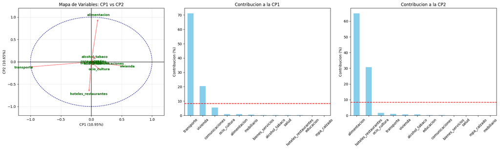

```python
plot_pca_complete_analysis(matriz_cargas_rotadas, contribuciones, pca, 1, 2)
```

- **CP1**: *Movilidad frente a Vivienda*. Diferencia los hogares con presupuestoi en movilidad frente a los que tienen repartido su preseupuesto en vivienda y comunicaciones.
- **CP2**: *Alimentación en casa frente a restauración*. Separa el gasto de "comer en casa" frente al estilo de vida de "comida fuera del hogar".

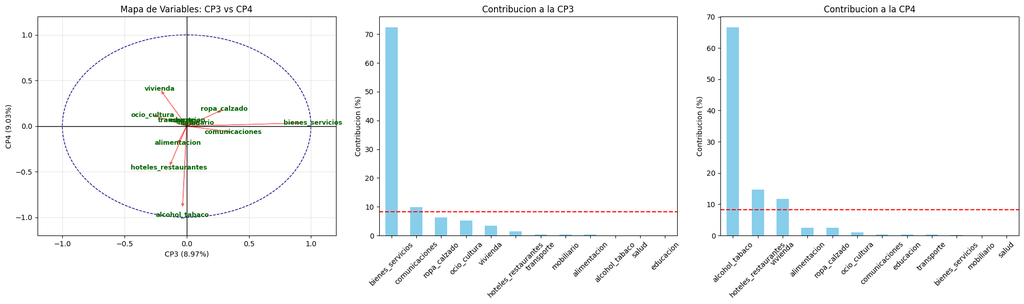

```python
plot_pca_complete_analysis(matriz_cargas_rotadas, contribuciones, pca, 3, 4)
```

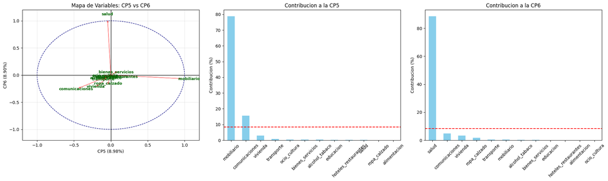

```python
plot_pca_complete_analysis(matriz_cargas_rotadas, contribuciones, pca, 5, 6)
```

- **CP5**: *Equipamiento del hogar*. Hogares con peso alto en equipamiento del hogar frente a peso ligero en comunicaciones.
- **CP6**: *Salud*. Presupuesto destinado de forma clarísima a la salud.

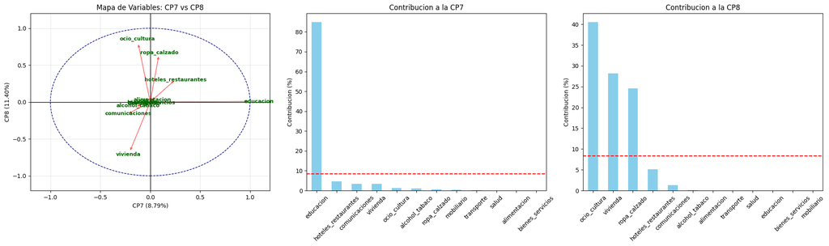

```python
plot_pca_complete_analysis(matriz_cargas_rotadas, contribuciones, pca, 7, 8)
```

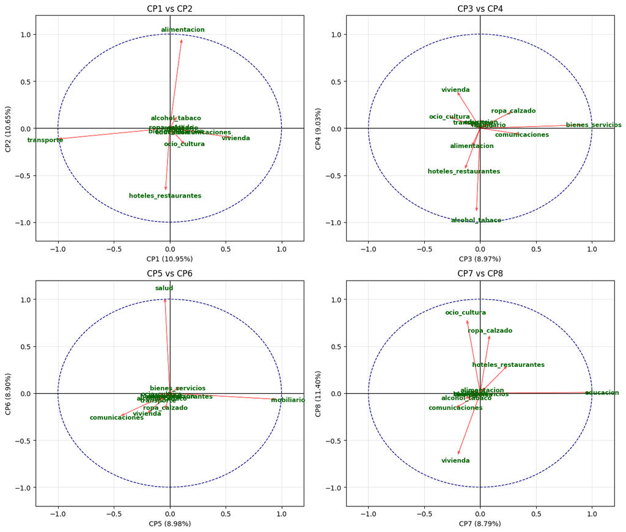

```python
fig, axes = plt.subplots(2, 2, figsize=(13, 11))

pares = [(1, 2), (3, 4), (5, 6), (7, 8)]

for ax, (pc_x, pc_y) in zip(axes.ravel(), pares):
    plot_pca_biplot(ax, matriz_cargas_rotadas, pca, pc_x, pc_y, coordenadas_hogares_train_rot)

plt.tight_layout()
plt.show()
```

```python
cp_vars = {
    'CP1': 'movilidad_vs_vivienda',
    'CP2': 'alimentacion_vs_restauracion',
    'CP3': 'otros_bienes_servicios_personales',
    'CP4': 'vivienda_vs_restauracion_alcohol_tabaco',
    'CP5': 'equipamiento_hogar',
    'CP6': 'salud',
    'CP7': 'educacion',
    'CP8': 'ocio_imagen_personal_vs_vivienda',
}

datos_train = datos_train.rename(columns=cp_vars)
datos_test = datos_test.rename(columns=cp_vars)

cp_nombres = list(cp_vars.values())
```

### Selección del número de clusters

|  | k | Inercia | Silueta | Pseudo F | Tamaño cluster más pequeño (%) | Tamaño cluster más grande (%) |
| --- | --- | --- | --- | --- | --- | --- |
| 0 | 2 | 116764.136951 | 0.150205 | 2271.655859 | 47.788588 | 52.211412 |
| 1 | 3 | 106900.616171 | 0.123523 | 1909.034410 | 27.668530 | 37.431864 |
| 2 | 4 | 97966.585700 | 0.136425 | 1829.087282 | 11.902298 | 32.912440 |
| 3 | 5 | 89838.231459 | 0.153097 | 1823.546773 | 7.182778 | 28.572414 |
| 4 | 6 | 82297.401700 | 0.166877 | 1857.880799 | 3.822535 | 27.716829 |
| 5 | 7 | 75446.319660 | 0.176351 | 1907.947322 | 3.698337 | 23.935693 |
| 6 | 8 | 70027.479586 | 0.183797 | 1921.942904 | 3.463741 | 21.755330 |
| 7 | 9 | 64720.146381 | 0.186663 | 1967.941864 | 3.353343 | 20.906645 |
| 8 | 10 | 60792.379803 | 0.186235 | 1966.145678 | 2.973849 | 20.209756 |
| 9 | 11 | 58503.186472 | 0.169003 | 1895.314733 | 3.111847 | 18.581384 |
| 10 | 12 | 56753.580447 | 0.161023 | 1816.589698 | 3.084248 | 17.808597 |
| 11 | 13 | 55150.036388 | 0.159174 | 1748.594664 | 2.877251 | 14.503553 |
| 12 | 14 | 53641.521366 | 0.159856 | 1690.687218 | 1.138481 | 13.344373 |
| 13 | 15 | 52186.793571 | 0.158535 | 1642.398380 | 1.138481 | 12.405989 |
| 14 | 16 | 50743.045646 | 0.159213 | 1603.871406 | 0.903885 | 12.033395 |
| 15 | 17 | 49512.970001 | 0.145955 | 1563.353720 | 0.883185 | 11.239909 |
| 16 | 18 | 48493.565725 | 0.142413 | 1520.121202 | 0.896985 | 9.825433 |
| 17 | 19 | 47522.594088 | 0.142349 | 1481.336958 | 0.876285 | 9.894432 |

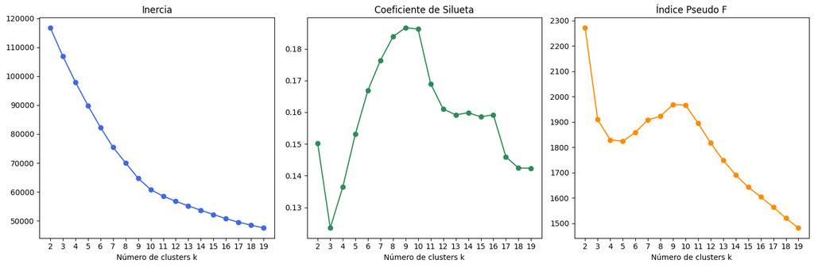

```python
k_values = range(2, 20)

resultados_k = []

X_cp_train = datos_train[cp_nombres].values
X_cp_test = datos_test[cp_nombres].values

for k in k_values:
    km = KMeans(
        n_clusters=k,
        n_init=100,
        random_state=111104
    )

    labels = km.fit_predict(X_cp_train)

    sizes = pd.Series(labels).value_counts(normalize=True).sort_index()

    resultados_k.append({
        "k": k,
        "Inercia": km.inertia_,
        "Silueta": silhouette_score(X_cp_train, labels),
        "Pseudo F": calinski_harabasz_score(X_cp_train, labels),
        "Tamaño cluster más pequeño (%)": sizes.min() * 100,
        "Tamaño cluster más grande (%)": sizes.max() * 100
    })

metricas_cluster = pd.DataFrame(resultados_k)

display(metricas_cluster)

fig, axes = plt.subplots(1, 3, figsize=(15, 5))

axes[0].plot(metricas_cluster["k"], metricas_cluster["Inercia"], marker="o", color="royalblue")
axes[0].set_title("Inercia")
axes[0].set_xlabel("Número de clusters k")
axes[0].set_xticks(metricas_cluster["k"])

axes[1].plot(metricas_cluster["k"], metricas_cluster["Silueta"], marker="o", color="seagreen")
axes[1].set_title("Coeficiente de Silueta")
axes[1].set_xlabel("Número de clusters k")
axes[1].set_xticks(metricas_cluster["k"])

axes[2].plot(metricas_cluster["k"], metricas_cluster["Pseudo F"], marker="o", color="darkorange")
axes[2].set_title("Índice Pseudo F")
axes[2].set_xlabel("Número de clusters k")
axes[2].set_xticks(metricas_cluster["k"])

plt.tight_layout()
plt.show()
```

Para determinar el número óptimo de tipologías (k), se evaluan particiones desde 2 hasta 19.

Nos quedaremos en $k=9$, ya que las medidas son muy parecidas entre 9 y 10, y coger un grupo más sería meter ruido y sobreajustar el futuro modelo.

### Interpretación de los clusters

```python
def resumen_clusters_k(X_scaled_df, df, cp_vars, k, random_state=111104):
    km = KMeans(
        n_clusters=k,
        n_init=100,
        random_state=random_state
    )

    labels = km.fit_predict(X_scaled_df)

    col_cluster = f"cluster_k{k}"
    if hasattr(X_scaled_df, "index"):
        idx = X_scaled_df.index
    else:
        idx = df.index
    df.loc[idx, col_cluster] = labels

    centroides = pd.DataFrame(
        km.cluster_centers_,
        columns=cp_vars
    )

    centroides.index = [f"Cluster {i}" for i in range(k)]

    tamanos = (
        pd.Series(labels)
        .value_counts()
        .sort_index()
        .to_frame("n")
    )
    tamanos["%"] = 100 * tamanos["n"] / tamanos["n"].sum()
    tamanos.index = [f"Cluster {i}" for i in range(k)]

    return centroides.round(3), tamanos.round(2), labels

centroides_9, tamanos_9, labels_9 = resumen_clusters_k(
    X_cp_train, datos_train, cp_vars.values(), k=9
)

kmeans_final = KMeans(n_clusters=9, n_init=100, random_state=111104)
datos_train['cluster_9'] = kmeans_final.fit_predict(X_cp_train)
datos_test['cluster_9'] = kmeans_final.predict(X_cp_test)
columnas_gasto = proporciones

perfil_gasto = datos_train.groupby('cluster_9')[columnas_gasto].mean() * 100

nombres_clusters = {
    0: "Ocio y restauración",
    1: "Movilidad intensiva",
    2: "Educación",
    3: "Alcohol y tabaco",
    4: "Vivienda",
    5: "Bienes, servicios e imagen personal",
    6: "Equipamiento del hogar",
    7: "Consumo básico doméstico",
    8: "Salud",
}

datos_train["perfil_consumo"] = datos_train["cluster_9"].map(nombres_clusters)
datos_test["perfil_consumo"] = datos_test["cluster_9"].map(nombres_clusters)

print("Tamaños k=9")
display(tamanos_9.transpose())
print("\nCentroides k=9")
display(centroides_9)
print("\nPerfil de gasto k=9")
display(perfil_gasto.round(2))
```

```
Tamaños k=9
```

|  | Cluster 0 | Cluster 1 | Cluster 2 | Cluster 3 | Cluster 4 | Cluster 5 | Cluster 6 | Cluster 7 | Cluster 8 |
| --- | --- | --- | --- | --- | --- | --- | --- | --- | --- |
| n | 3030.00 | 1520.00 | 486.00 | 759.00 | 2839.00 | 1411.00 | 519.00 | 3030.00 | 899.0 |
| % | 20.91 | 10.49 | 3.35 | 5.24 | 19.59 | 9.74 | 3.58 | 20.91 | 6.2 |

```
Centroides k=9
```

|  | movilidad_vs_vivienda | alimentacion_vs_restauracion | otros_bienes_servicios_personales | vivienda_vs_restauracion_alcohol_tabaco | equipamiento_hogar | salud | educacion | ocio_imagen_personal_vs_vivienda |
| --- | --- | --- | --- | --- | --- | --- | --- | --- |
| Cluster 0 | -0.058 | -0.918 | -0.358 | -0.154 | 0.013 | -0.107 | 0.166 | 1.293 |
| Cluster 1 | -2.467 | -0.366 | -0.313 | 0.155 | -0.175 | -0.110 | -0.099 | -0.087 |
| Cluster 2 | 0.079 | -0.342 | 0.030 | 0.288 | -0.220 | -0.162 | 4.134 | -0.014 |
| Cluster 3 | 0.192 | 0.289 | -0.150 | -2.980 | -0.266 | -0.283 | -0.360 | -0.197 |
| Cluster 4 | 0.880 | -0.206 | -0.287 | 0.649 | -0.502 | -0.430 | -0.465 | -1.229 |
| Cluster 5 | 0.223 | -0.113 | 2.008 | 0.283 | -0.084 | -0.123 | -0.092 | 0.189 |
| Cluster 6 | 0.373 | -0.185 | 0.154 | 0.302 | 3.580 | -0.291 | -0.294 | -0.209 |
| Cluster 7 | 0.184 | 1.347 | -0.140 | -0.058 | 0.102 | -0.126 | -0.107 | -0.059 |
| Cluster 8 | 0.197 | 0.048 | -0.015 | 0.143 | -0.098 | 3.017 | -0.178 | -0.132 |

```
Perfil de gasto k=9
```

| cluster_9 | prop_alimentacion | prop_alcohol_tabaco | prop_ropa_calzado | prop_vivienda | prop_mobiliario | prop_salud | prop_transporte | prop_comunicaciones | prop_ocio_cultura | prop_educacion | prop_hoteles_restaurantes | prop_bienes_servicios |
| --- | --- | --- | --- | --- | --- | --- | --- | --- | --- | --- | --- | --- |
| 0 | 12.77 | 0.99 | 6.00 | 26.91 | 3.22 | 2.63 | 8.61 | 2.56 | 10.41 | 0.96 | 18.85 | 6.09 |
| 1 | 12.07 | 0.98 | 2.87 | 23.66 | 2.46 | 2.45 | 36.41 | 2.26 | 3.06 | 0.67 | 7.72 | 5.40 |
| 2 | 13.66 | 0.71 | 4.15 | 29.85 | 3.11 | 2.73 | 7.97 | 2.74 | 3.78 | 13.40 | 10.75 | 7.13 |
| 3 | 19.85 | 11.35 | 2.68 | 29.78 | 3.04 | 2.19 | 6.99 | 3.48 | 3.23 | 0.45 | 10.73 | 6.23 |
| 4 | 14.33 | 0.67 | 1.76 | 58.51 | 2.35 | 1.79 | 3.81 | 3.99 | 1.95 | 0.25 | 4.50 | 6.10 |
| 5 | 15.30 | 0.77 | 6.65 | 32.32 | 3.59 | 2.91 | 6.28 | 4.10 | 3.24 | 0.69 | 6.54 | 17.62 |
| 6 | 13.88 | 0.78 | 3.18 | 32.50 | 23.08 | 2.25 | 4.91 | 2.19 | 3.24 | 0.56 | 6.25 | 7.17 |
| 7 | 32.00 | 1.31 | 3.44 | 33.69 | 3.88 | 2.47 | 6.00 | 2.88 | 3.23 | 0.41 | 4.12 | 6.57 |
| 8 | 16.36 | 1.03 | 2.74 | 31.04 | 3.13 | 21.62 | 5.41 | 2.51 | 3.16 | 0.44 | 5.87 | 6.70 |

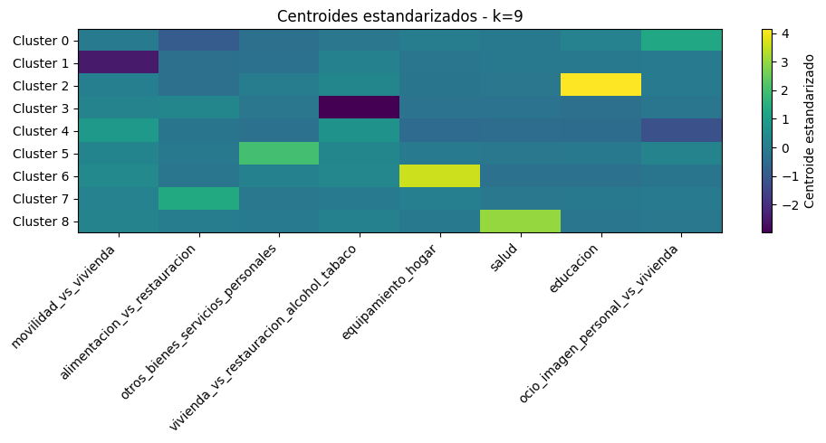

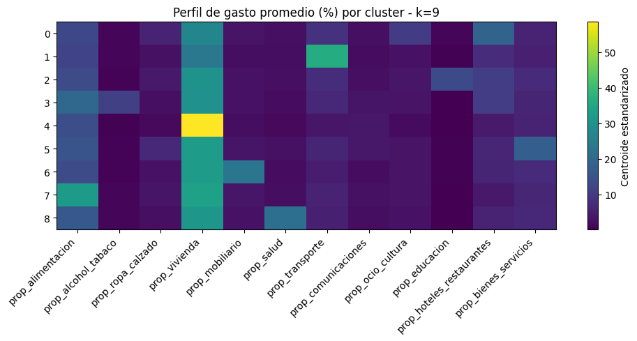

```python
def plot_centroides(centroides, titulo):
    plt.figure(figsize=(10, 5))
    plt.imshow(centroides, aspect="auto")
    plt.colorbar(label="Centroide estandarizado")
    plt.xticks(range(len(centroides.columns)), centroides.columns, rotation=45, ha="right")
    plt.yticks(range(len(centroides.index)), centroides.index)
    plt.title(titulo)
    plt.tight_layout()
    plt.show()

plot_centroides(centroides_9, "Centroides estandarizados - k=9")
plot_centroides(perfil_gasto, "Perfil de gasto promedio (%) por cluster - k=9")
```

### Caracterización sociodemográfica

```
Desviación respecto a la media global (puntos porcentuales)
```

| cluster_9 | prop_alimentacion | prop_alcohol_tabaco | prop_ropa_calzado | prop_vivienda | prop_mobiliario | prop_salud | prop_transporte | prop_comunicaciones | prop_ocio_cultura | prop_educacion | prop_hoteles_restaurantes | prop_bienes_servicios |
| --- | --- | --- | --- | --- | --- | --- | --- | --- | --- | --- | --- | --- |
| 0 | -5.16 | -0.51 | 2.17 | -8.49 | -0.62 | -0.95 | -0.77 | -0.51 | 5.93 | -0.03 | 10.21 | -1.27 |
| 1 | -5.86 | -0.52 | -0.96 | -11.75 | -1.37 | -1.14 | 27.03 | -0.81 | -1.42 | -0.32 | -0.92 | -1.96 |
| 2 | -4.27 | -0.78 | 0.32 | -5.55 | -0.73 | -0.86 | -1.40 | -0.32 | -0.70 | 12.41 | 2.11 | -0.23 |
| 3 | 1.92 | 9.85 | -1.15 | -5.62 | -0.80 | -1.39 | -2.39 | 0.42 | -1.25 | -0.55 | 2.09 | -1.14 |
| 4 | -3.60 | -0.83 | -2.07 | 23.10 | -1.49 | -1.80 | -5.56 | 0.93 | -2.53 | -0.75 | -4.14 | -1.26 |
| 5 | -2.63 | -0.73 | 2.82 | -3.09 | -0.25 | -0.68 | -3.10 | 1.04 | -1.23 | -0.30 | -2.10 | 10.26 |
| 6 | -4.05 | -0.72 | -0.65 | -2.91 | 19.24 | -1.33 | -4.47 | -0.87 | -1.24 | -0.43 | -2.38 | -0.19 |
| 7 | 14.07 | -0.19 | -0.39 | -1.72 | 0.05 | -1.11 | -3.37 | -0.18 | -1.25 | -0.58 | -4.52 | -0.79 |
| 8 | -1.57 | -0.47 | -1.09 | -4.37 | -0.71 | 18.03 | -3.96 | -0.56 | -1.32 | -0.55 | -2.77 | -0.66 |

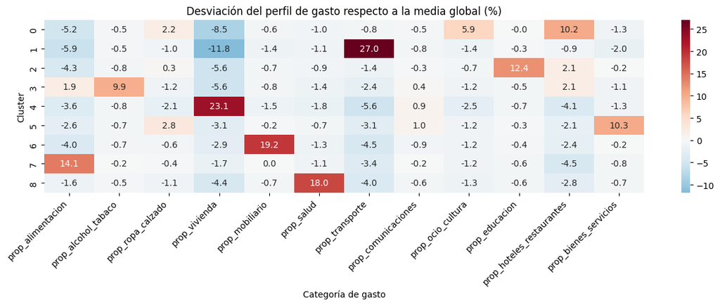

```python
cluster_col = "perfil_consumo"
datos_caracterizacion = datos_train.copy()

suple_numericas = [
    "tamano_ocde", "n_menores", "n_mayores", "n_ocupados",
    "log_ingresos_hogar", "n_habitaciones", "log_gasto_total_crudo"
]

suple_categoricas = [
    "c_autonoma", "tam_municipio", "hombre",
    "ocupado", "estudios", "sector_publico_imp", "alquiler",
    "tipo_hogar", "edad"
]

categoricas_graficar = [
    "tipo_hogar", "edad", "ocupado", "estudios", "tam_municipio"
]

orden_clusters = sorted(datos_caracterizacion[cluster_col].dropna().unique())

media_global = datos_caracterizacion[proporciones].mean() * 100
desv_gasto = perfil_gasto - media_global

print("Desviación respecto a la media global (puntos porcentuales)")
display(desv_gasto.round(2))

plt.figure(figsize=(13, 5))
sns.heatmap(desv_gasto, cmap="RdBu_r", center=0, annot=True, fmt=".1f")
plt.title("Desviación del perfil de gasto respecto a la media global (%)")
plt.xlabel("Categoría de gasto")
plt.ylabel("Cluster")
plt.xticks(rotation=45, ha="right")
plt.tight_layout()
plt.show()
```

```
Perfil medio de gasto (%) por cluster
```

| perfil_consumo | prop_alimentacion | prop_alcohol_tabaco | prop_ropa_calzado | prop_vivienda | prop_mobiliario | prop_salud | prop_transporte | prop_comunicaciones | prop_ocio_cultura | prop_educacion | prop_hoteles_restaurantes | prop_bienes_servicios |
| --- | --- | --- | --- | --- | --- | --- | --- | --- | --- | --- | --- | --- |
| Alcohol y tabaco | 19.85 | 11.35 | 2.68 | 29.78 | 3.04 | 2.19 | 6.99 | 3.48 | 3.23 | 0.45 | 10.73 | 6.23 |
| Bienes, servicios e imagen personal | 15.30 | 0.77 | 6.65 | 32.32 | 3.59 | 2.91 | 6.28 | 4.10 | 3.24 | 0.69 | 6.54 | 17.62 |
| Consumo básico doméstico | 32.00 | 1.31 | 3.44 | 33.69 | 3.88 | 2.47 | 6.00 | 2.88 | 3.23 | 0.41 | 4.12 | 6.57 |
| Educación | 13.66 | 0.71 | 4.15 | 29.85 | 3.11 | 2.73 | 7.97 | 2.74 | 3.78 | 13.40 | 10.75 | 7.13 |
| Equipamiento del hogar | 13.88 | 0.78 | 3.18 | 32.50 | 23.08 | 2.25 | 4.91 | 2.19 | 3.24 | 0.56 | 6.25 | 7.17 |
| Movilidad intensiva | 12.07 | 0.98 | 2.87 | 23.66 | 2.46 | 2.45 | 36.41 | 2.26 | 3.06 | 0.67 | 7.72 | 5.40 |
| Ocio y restauración | 12.77 | 0.99 | 6.00 | 26.91 | 3.22 | 2.63 | 8.61 | 2.56 | 10.41 | 0.96 | 18.85 | 6.09 |
| Salud | 16.36 | 1.03 | 2.74 | 31.04 | 3.13 | 21.62 | 5.41 | 2.51 | 3.16 | 0.44 | 5.87 | 6.70 |
| Vivienda | 14.33 | 0.67 | 1.76 | 58.51 | 2.35 | 1.79 | 3.81 | 3.99 | 1.95 | 0.25 | 4.50 | 6.10 |

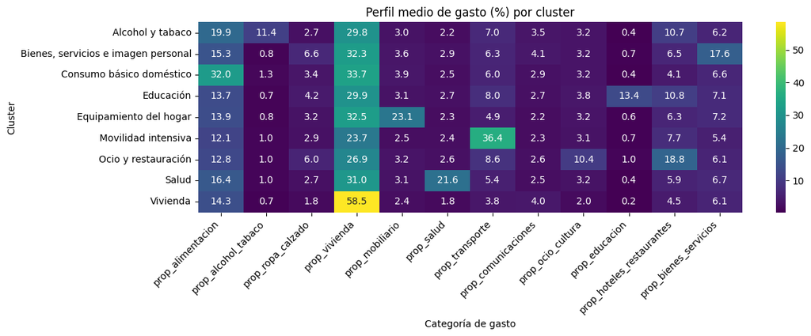

```python
perfil_gasto = datos_caracterizacion.groupby(cluster_col)[proporciones].mean().loc[orden_clusters] * 100

print("Perfil medio de gasto (%) por cluster")
display(perfil_gasto.round(2))

plt.figure(figsize=(13, 5))
sns.heatmap(perfil_gasto, cmap="viridis", annot=True, fmt=".1f")
plt.title("Perfil medio de gasto (%) por cluster")
plt.xlabel("Categoría de gasto")
plt.ylabel("Cluster")
plt.xticks(rotation=45, ha="right")
plt.tight_layout()
plt.show()
```

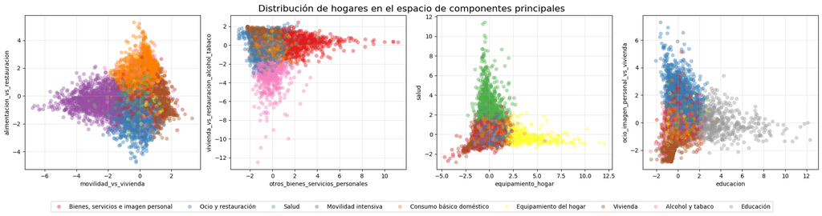

```python
fig, axes = plt.subplots(1, 4, figsize=(20, 5))

sns.scatterplot(data=datos_train, x='movilidad_vs_vivienda', y='alimentacion_vs_restauracion', hue='perfil_consumo',
                ax=axes[0], palette='Set1', alpha=0.4, edgecolor=None)

sns.scatterplot(data=datos_train, x='otros_bienes_servicios_personales', y='vivienda_vs_restauracion_alcohol_tabaco', hue='perfil_consumo',
                ax=axes[1], palette='Set1', alpha=0.4, edgecolor=None)

sns.scatterplot(data=datos_train, x='equipamiento_hogar', y='salud', hue='perfil_consumo',
                ax=axes[2], palette='Set1', alpha=0.4, edgecolor=None)

sns.scatterplot(data=datos_train, x='educacion', y='ocio_imagen_personal_vs_vivienda', hue='perfil_consumo',
                ax=axes[3], palette='Set1', alpha=0.4, edgecolor=None)

handles, labels = axes[0].get_legend_handles_labels()
labels_formateadas = []
for label in labels:
    try:
        cluster_id = int(float(label))
        nombre = nombres_clusters.get(cluster_id, str(cluster_id))
        labels_formateadas.append(f"{cluster_id}: {nombre}")
    except ValueError:
        labels_formateadas.append(label)

for ax in axes:
    ax.legend().remove()
    ax.grid(True, alpha=0.3)

fig.legend(
    handles,
    labels_formateadas,
    loc='lower center',
    ncol=9,
    bbox_to_anchor=(0.5, 0)
)

plt.tight_layout()
plt.subplots_adjust(bottom=0.22)
plt.suptitle("Distribución de hogares en el espacio de componentes principales", y=1.02, fontsize=16)
plt.show()
```

```python
def cramers_v(tabla, corregida=True):
    chi2, p, dof, expected = chi2_contingency(tabla)
    n = tabla.to_numpy().sum()
    r, k = tabla.shape

    if not corregida:
        v = np.sqrt((chi2 / n) / min(r - 1, k - 1))
        return v, p

    phi2 = chi2 / n
    phi2_corr = max(0, phi2 - ((k - 1) * (r - 1)) / (n - 1))
    r_corr = r - ((r - 1) ** 2) / (n - 1)
    k_corr = k - ((k - 1) ** 2) / (n - 1)

    v_corr = np.sqrt(phi2_corr / min(k_corr - 1, r_corr - 1))
    return v_corr, p

def residuos_corregidos(tabla):
    chi2, p, dof, expected = chi2_contingency(tabla)
    expected = pd.DataFrame(expected, index=tabla.index, columns=tabla.columns)

    n = tabla.to_numpy().sum()
    prop_fila = tabla.sum(axis=1) / n
    prop_col = tabla.sum(axis=0) / n

    residuos = pd.DataFrame(index=tabla.index, columns=tabla.columns, dtype=float)

    for i in tabla.index:
        for j in tabla.columns:
            residuos.loc[i, j] = (
                (tabla.loc[i, j] - expected.loc[i, j]) /
                np.sqrt(
                    expected.loc[i, j]
                    * (1 - prop_fila.loc[i])
                    * (1 - prop_col.loc[j])
                )
            )

    return residuos
```

```
V de Cramer: 0.159
p-valor chi-cuadrado: 0.0
```

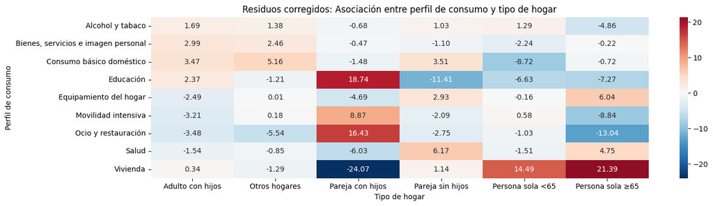

```python
tabla_tipo_hogar = pd.crosstab(
    datos_caracterizacion[cluster_col],
    datos_caracterizacion["tipo_hogar"]
)

v_tipo_hogar, p_tipo_hogar = cramers_v(tabla_tipo_hogar)
res_tipo_hogar = residuos_corregidos(tabla_tipo_hogar)

print("V de Cramer:", round(v_tipo_hogar, 3))
print("p-valor chi-cuadrado:", p_tipo_hogar)

plt.figure(figsize=(15, max(3, 0.45 * res_tipo_hogar.shape[0])))
sns.heatmap(res_tipo_hogar, cmap="RdBu_r", center=0, annot=True, fmt=".2f")
plt.title("Residuos corregidos: Asociación entre perfil de consumo y tipo de hogar")
plt.xlabel("Tipo de hogar")
plt.ylabel("Perfil de consumo")
plt.tight_layout()
plt.show()
```

```
V de Cramer: 0.168
p-valor chi-cuadrado: 1.3899865236864994e-248
```

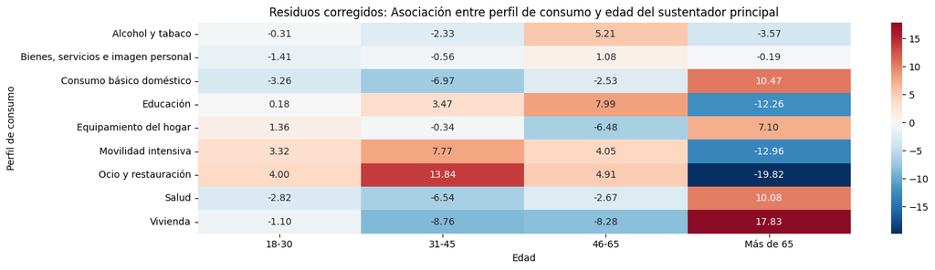

```python
tabla_edad = pd.crosstab(
    datos_caracterizacion[cluster_col],
    datos_caracterizacion["edad"]
)

v_edad, p_edad = cramers_v(tabla_edad)
res_edad = residuos_corregidos(tabla_edad)

print("V de Cramer:", round(v_edad, 3))
print("p-valor chi-cuadrado:", p_edad)

plt.figure(figsize=(15, max(3, 0.45 * res_edad.shape[0])))
sns.heatmap(res_edad, cmap="RdBu_r", center=0, annot=True, fmt=".2f")
plt.title("Residuos corregidos: Asociación entre perfil de consumo y edad del sustentador principal")
plt.xlabel("Edad")
plt.ylabel("Perfil de consumo")
plt.tight_layout()
plt.show()
```

```
V de Cramer: 0.196
p-valor chi-cuadrado: 1.6242413152826554e-231
```

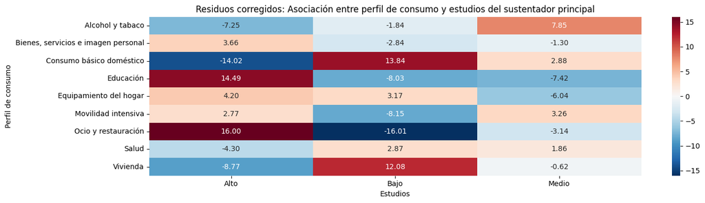

```python
tabla_estudios = pd.crosstab(
    datos_caracterizacion[cluster_col],
    datos_caracterizacion["estudios"]
)

v_estudios, p_estudios = cramers_v(tabla_estudios)
res_estudios = residuos_corregidos(tabla_estudios)

print("V de Cramer:", round(v_estudios, 3))
print("p-valor chi-cuadrado:", p_estudios)

plt.figure(figsize=(15, max(3, 0.45 * res_estudios.shape[0])))
sns.heatmap(res_estudios, cmap="RdBu_r", center=0, annot=True, fmt=".2f")
plt.title("Residuos corregidos: Asociación entre perfil de consumo y estudios del sustentador principal")
plt.xlabel("Estudios")
plt.ylabel("Perfil de consumo")
plt.tight_layout()
plt.show()
```

```
V de Cramer: 0.108
p-valor chi-cuadrado: 4.618988816337891e-34
```

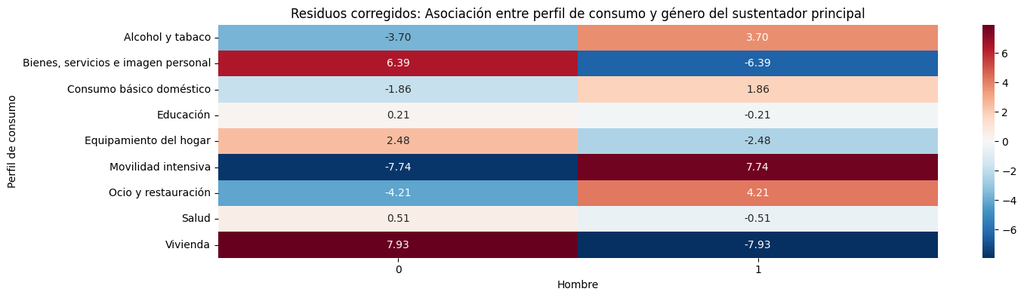

```python
tabla_hombre = pd.crosstab(
    datos_caracterizacion[cluster_col],
    datos_caracterizacion["hombre"]
)

v_hombre, p_hombre = cramers_v(tabla_hombre)
res_hombre = residuos_corregidos(tabla_hombre)

print("V de Cramer:", round(v_hombre, 3))
print("p-valor chi-cuadrado:", p_hombre)

plt.figure(figsize=(15, max(3, 0.45 * res_hombre.shape[0])))
sns.heatmap(res_hombre, cmap="RdBu_r", center=0, annot=True, fmt=".2f")
plt.title("Residuos corregidos: Asociación entre perfil de consumo y género del sustentador principal")
plt.xlabel("Hombre")
plt.ylabel("Perfil de consumo")
plt.tight_layout()
plt.show()
```

```
V de Cramer: 0.313
p-valor chi-cuadrado: 3.3970320091712247e-302
```

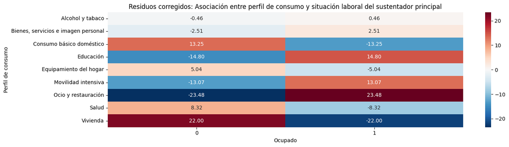

```python
tabla_ocupado = pd.crosstab(
    datos_caracterizacion[cluster_col],
    datos_caracterizacion["ocupado"]
)

v_ocupado, p_ocupado = cramers_v(tabla_ocupado)
res_ocupado = residuos_corregidos(tabla_ocupado)

print("V de Cramer:", round(v_ocupado, 3))
print("p-valor chi-cuadrado:", p_ocupado)

plt.figure(figsize=(15, max(3, 0.45 * res_ocupado.shape[0])))
sns.heatmap(res_ocupado, cmap="RdBu_r", center=0, annot=True, fmt=".2f")
plt.title("Residuos corregidos: Asociación entre perfil de consumo y situación laboral del sustentador principal")
plt.xlabel("Ocupado")
plt.ylabel("Perfil de consumo")
plt.tight_layout()
plt.show()
```

```
V de Cramer: 0.096
p-valor chi-cuadrado: 8.204840597615395e-27
```

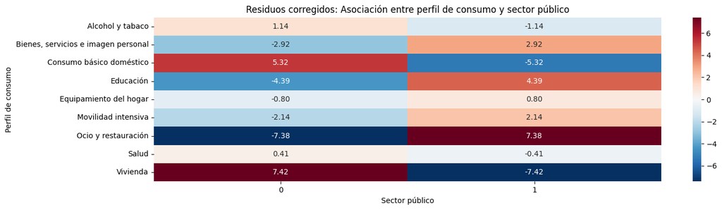

```python
tabla_sector_publico = pd.crosstab(
    datos_caracterizacion[cluster_col],
    datos_caracterizacion["sector_publico_imp"]
)

v_sector_publico, p_sector_publico = cramers_v(tabla_sector_publico)
res_sector_publico = residuos_corregidos(tabla_sector_publico)

print("V de Cramer:", round(v_sector_publico, 3))
print("p-valor chi-cuadrado:", p_sector_publico)

plt.figure(figsize=(15, max(3, 0.45 * res_sector_publico.shape[0])))
sns.heatmap(res_sector_publico, cmap="RdBu_r", center=0, annot=True, fmt=".2f")
plt.title("Residuos corregidos: Asociación entre perfil de consumo y sector público")
plt.xlabel("Sector público")
plt.ylabel("Perfil de consumo")
plt.tight_layout()
plt.show()
```

```
V de Cramer: 0.061
p-valor chi-cuadrado: 1.5509453131186202e-10
```

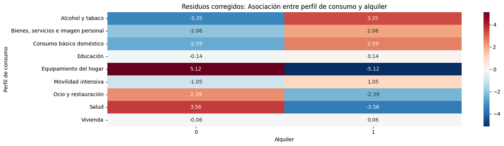

```python
tabla_alquiler = pd.crosstab(
    datos_caracterizacion[cluster_col],
    datos_caracterizacion["alquiler"]
)

v_alquiler, p_alquiler = cramers_v(tabla_alquiler)
res_alquiler = residuos_corregidos(tabla_alquiler)

print("V de Cramer:", round(v_alquiler, 3))
print("p-valor chi-cuadrado:", p_alquiler)

plt.figure(figsize=(15, max(3, 0.45 * res_alquiler.shape[0])))
sns.heatmap(res_alquiler, cmap="RdBu_r", center=0, annot=True, fmt=".2f")
plt.title("Residuos corregidos: Asociación entre perfil de consumo y alquiler")
plt.xlabel("Alquiler")
plt.ylabel("Perfil de consumo")
plt.tight_layout()
plt.show()
```

```
V de Cramer: 0.063
p-valor chi-cuadrado: 5.147839685569431e-29
```

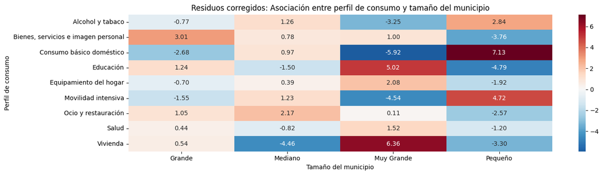

```python
tabla_tam_municipio = pd.crosstab(
    datos_caracterizacion[cluster_col],
    datos_caracterizacion["tam_municipio"]
)

v_tam_municipio, p_tam_municipio = cramers_v(tabla_tam_municipio)
res_tam_municipio = residuos_corregidos(tabla_tam_municipio)

print("V de Cramer:", round(v_tam_municipio, 3))
print("p-valor chi-cuadrado:", p_tam_municipio)

plt.figure(figsize=(15, max(3, 0.45 * res_tam_municipio.shape[0])))
sns.heatmap(res_tam_municipio, cmap="RdBu_r", center=0, annot=True, fmt=".2f")
plt.title("Residuos corregidos: Asociación entre perfil de consumo y tamaño del municipio")
plt.xlabel("Tamaño del municipio")
plt.ylabel("Perfil de consumo")
plt.tight_layout()
plt.show()
```

```
V de Cramer: 0.06
p-valor chi-cuadrado: 1.1105805347100178e-51
```

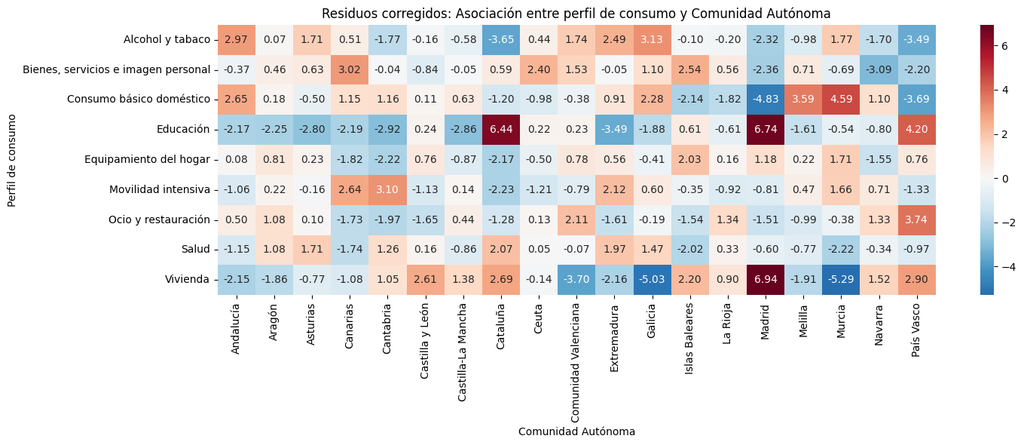

```python
tabla_c_autonoma = pd.crosstab(
    datos_caracterizacion[cluster_col],
    datos_caracterizacion["c_autonoma"]
)

v_c_autonoma, p_c_autonoma = cramers_v(tabla_c_autonoma)
res_c_autonoma = residuos_corregidos(tabla_c_autonoma)

print("V de Cramer:", round(v_c_autonoma, 3))
print("p-valor chi-cuadrado:", p_c_autonoma)

plt.figure(figsize=(15, max(6, 0.45 * res_c_autonoma.shape[0])))
sns.heatmap(res_c_autonoma, cmap="RdBu_r", center=0, annot=True, fmt=".2f")
plt.title("Residuos corregidos: Asociación entre perfil de consumo y Comunidad Autónoma")
plt.xlabel("Comunidad Autónoma")
plt.ylabel("Perfil de consumo")
plt.tight_layout()
plt.show()
```

```python
resultados_kw = []

for var in suple_numericas:
    df_var = datos_caracterizacion[[cluster_col, var]].dropna()

    grupos = [
        df_var.loc[df_var[cluster_col] == cl, var].values
        for cl in orden_clusters
        if (df_var[cluster_col] == cl).sum() > 0
    ]

    H, p = kruskal(*grupos)

    n = len(df_var)
    k = len(grupos)

    epsilon2 = (H - k + 1) / (n - k)
    epsilon2 = max(0, epsilon2)

    resultados_kw.append({
        "Variable": var,
        "p-valor": p,
        "epsilon2": epsilon2
    })

tabla_kw = pd.DataFrame(resultados_kw)

tabla_kw["p-valor_formato"] = tabla_kw["p-valor"].apply(
    lambda x: "$<0.001$" if x < 0.001 else f"{x:.3f}"
)

tabla_kw = tabla_kw[
    ["Variable", "p-valor_formato", "epsilon2"]
].sort_values("epsilon2", ascending=False)

print("Contraste de Kruskal-Wallis y tamaño de efecto")
display(tabla_kw)
```

```
Contraste de Kruskal-Wallis y tamaño de efecto
```

|  | Variable | p-valor_formato | epsilon2 |
| --- | --- | --- | --- |
| 6 | log_gasto_total_crudo | $<0.001$ | 0.245449 |
| 3 | n_ocupados | $<0.001$ | 0.128427 |
| 4 | log_ingresos_hogar | $<0.001$ | 0.117320 |
| 0 | tamano_ocde | $<0.001$ | 0.091830 |
| 2 | n_mayores | $<0.001$ | 0.056722 |
| 1 | n_menores | $<0.001$ | 0.056604 |
| 5 | n_habitaciones | $<0.001$ | 0.002139 |

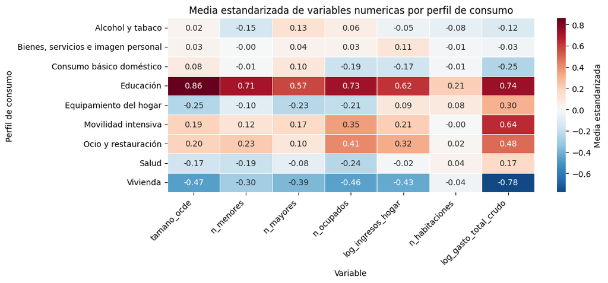

```python
suple_numericas_presentes = [
    var for var in suple_numericas
    if var in datos_caracterizacion.columns
]
faltantes = sorted(set(suple_numericas) - set(suple_numericas_presentes))
if faltantes:
    print("Variables no encontradas y omitidas:", ", ".join(faltantes))

resumen_num = (
    datos_caracterizacion
    .groupby(cluster_col)[suple_numericas_presentes]
    .mean()
    .loc[orden_clusters]
 )

media_global = datos_caracterizacion[suple_numericas_presentes].mean()
sd_global = datos_caracterizacion[suple_numericas_presentes].std()

resumen_num_std_plot = (resumen_num - media_global) / sd_global

plt.figure(figsize=(11, 5))
sns.heatmap(
    resumen_num_std_plot,
    cmap="RdBu_r",
    center=0,
    annot=True,
    fmt=".2f",
    linewidths=0.5,
    cbar_kws={"label": "Media estandarizada"}
 )

plt.title("Media estandarizada de variables numericas por perfil de consumo")
plt.xlabel("Variable")
plt.ylabel("Perfil de consumo")
plt.xticks(rotation=45, ha="right")
plt.yticks(rotation=0)
plt.tight_layout()
plt.show()
```

```python
datos_modelos = pd.concat(
    [datos_train, datos_test],
    axis=0
)

datos_modelos.to_csv(
    "../datos_procesados/datos_con_tipologia_consumo.csv",
    index=False
)
```